# EDA Case Study

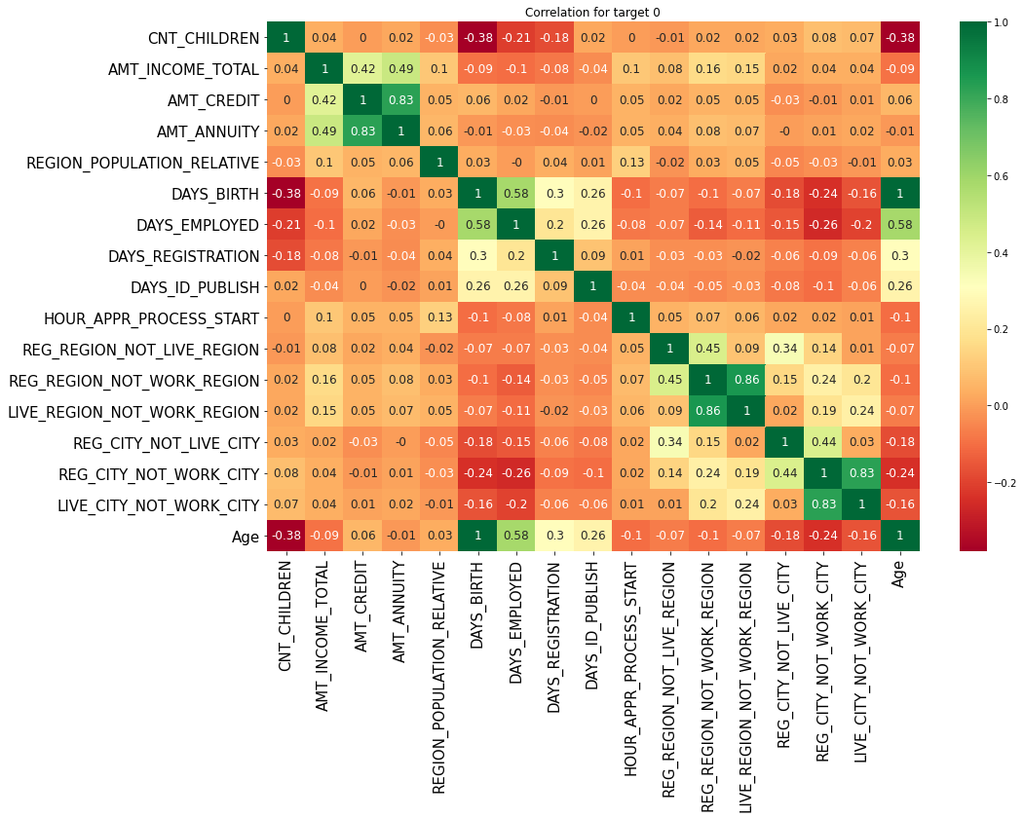

```python
# For Target 0

targets_corr(data=target0,title='Correlation for target 0')
```

From above correlation heatmap, we can point out following observations

1. Credit amount and age has very week corelation.
2. Ammount_Annuty and Amount Credit have high corelation.
3. Credit amount has o relation to the number of children client have.
4. Days Employed and Total income are showing inverse proportionality.

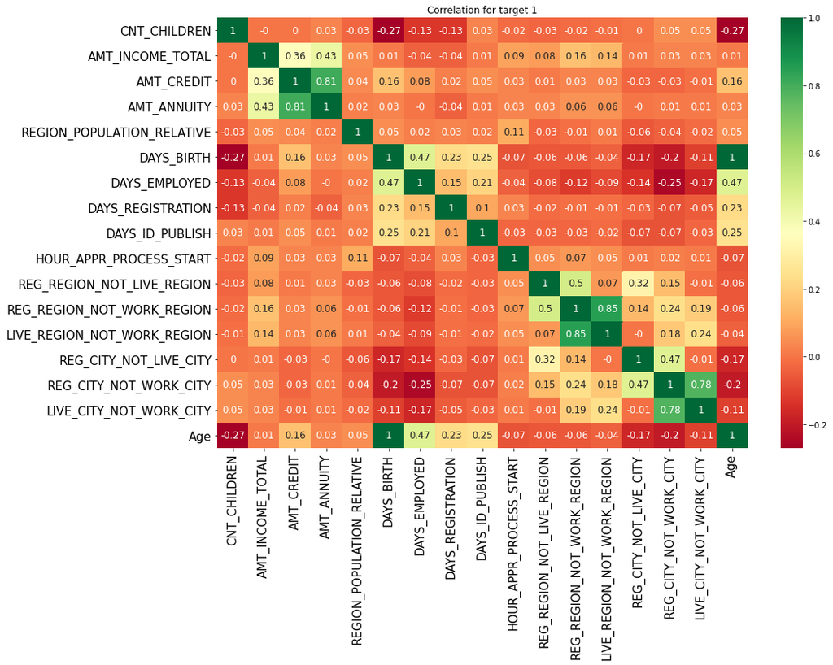

```python
# For Target 1

targets_corr(data=target1,title='Correlation for target 1')
```

For Target 1 : It is same observation just like Target 0.

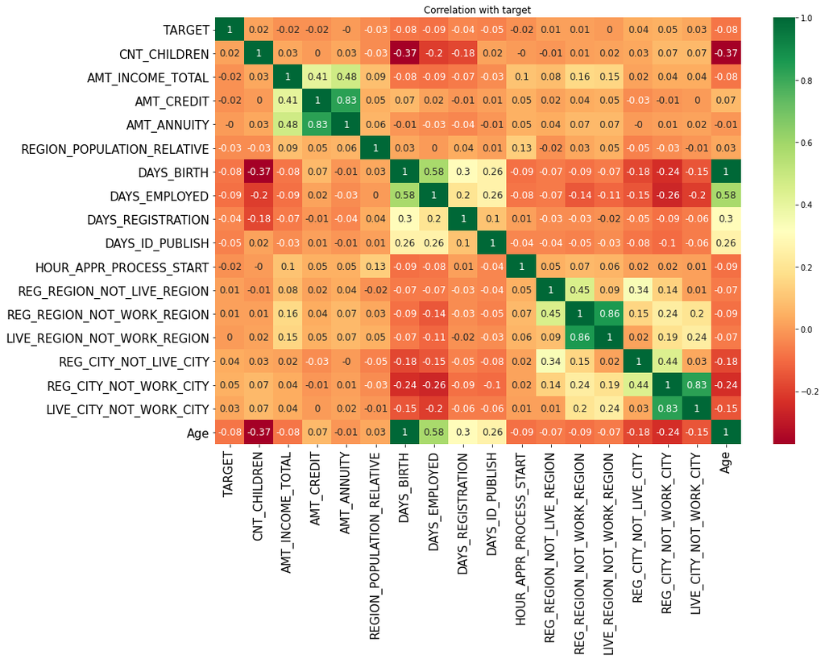

```python
targets_corr(data=total0and1,title='Correlation with target')
```

With the above plot, we can see that :

1. Amount income, Ammount Credit, Region Population Relative, Age, Days Employed, Days Registration had invers relation with target. Which means if these parameters are oing high this is leading to shift of target value towards 0. ( Explained in detail at end )

### Multivariate analysis for numerical variables

**For Target 0**

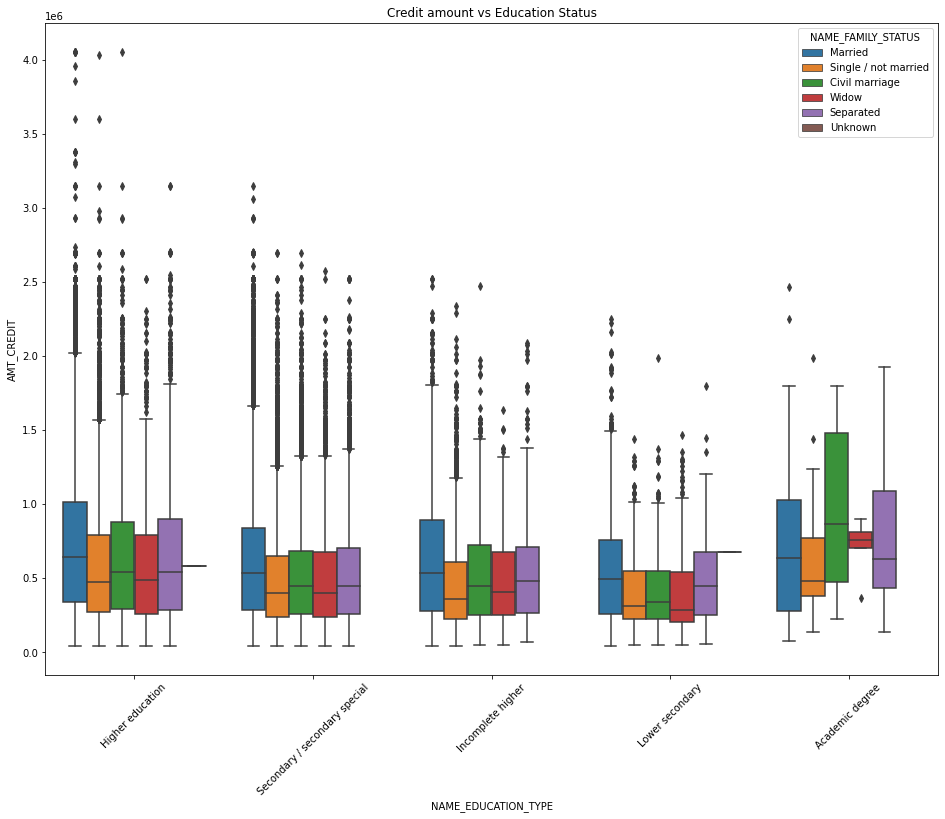

```python
# Box plotting for Credit amount

plt.figure(figsize=(16,12))
plt.xticks(rotation=45)
sns.boxplot(data =target0_df, x='NAME_EDUCATION_TYPE',y='AMT_CREDIT', hue ='NAME_FAMILY_STATUS',orient='v')
plt.title('Credit amount vs Education Status')
plt.show()
```

- From the above box plot we can conclude that Family status of 'civil marriage', 'marriage' and 'separated' of Academic degree education are having higher number of credits than others.
- Also, higher education of family status of 'marriage', 'single' and 'civil marriage' are having more outliers.
- Civil marriage for Academic degree is having most of the credits in the third quartile.

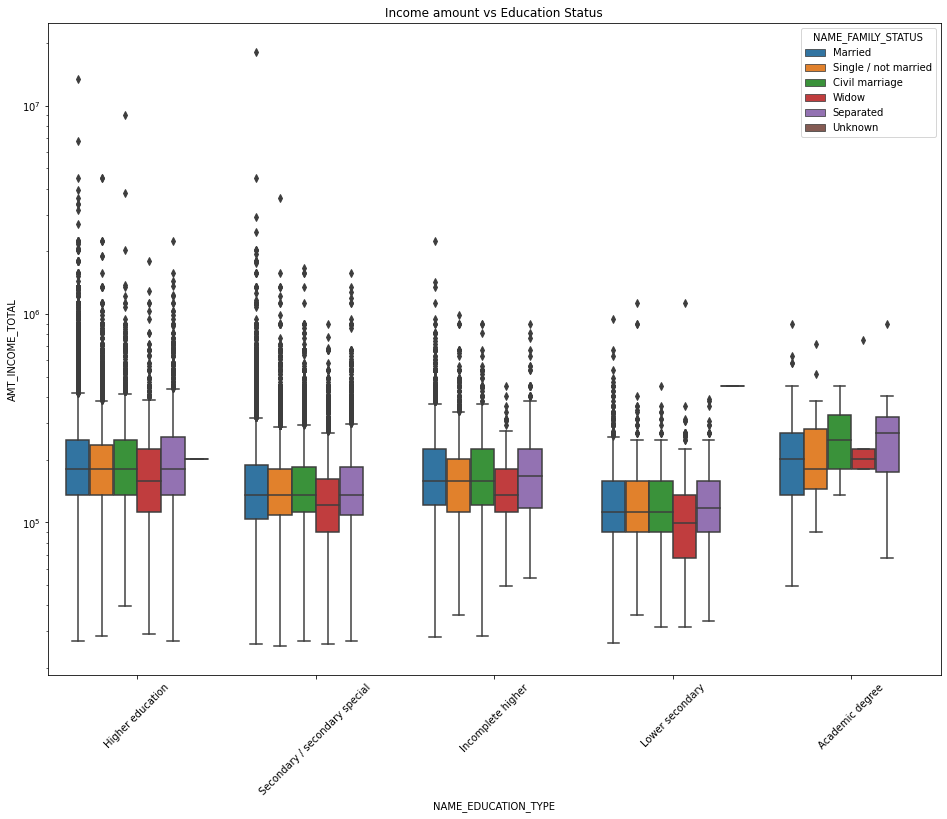

```python
# Box plotting for Income amount in logarithmic scale

plt.figure(figsize=(16,12))
plt.xticks(rotation=45)
plt.yscale('log')
sns.boxplot(data =target0_df, x='NAME_EDUCATION_TYPE',y='AMT_INCOME_TOTAL', hue ='NAME_FAMILY_STATUS',orient='v')
plt.title('Income amount vs Education Status')
plt.show()
```

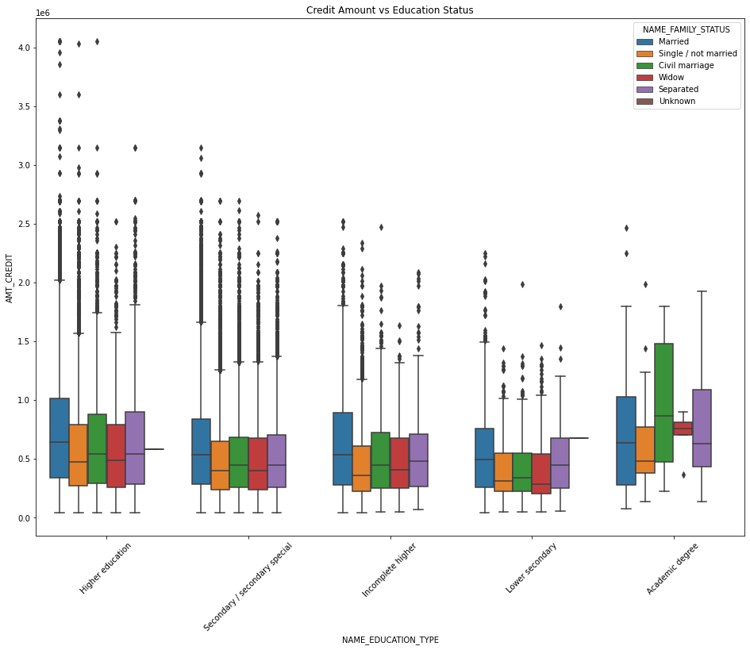

```python
# Box plotting for credit amount

plt.figure(figsize=(16,12))
plt.xticks(rotation=45)
sns.boxplot(data =target0_df, x='NAME_EDUCATION_TYPE',y='AMT_CREDIT', hue ='NAME_FAMILY_STATUS',orient='v')
plt.title('Credit Amount vs Education Status')
plt.show()
```